# Introduction to R: Session 4

Eleonora Minaeva, eleonora.minaeva@eui.eu

2023-09-30

# Correlation and regression analysis

## Barnett, Carolyn, 2023, “Women’s Rights and Misperceived Gender Norms Under Authoritarianism”. Comparative Political Studies

[figure not shown]

*Research question:* how does the promotion of women’s rights by an authoritarian government affect perceived norms, i.e. what individuals believe others value and how they believe others behave?

*Hypotheses:*

H1a: Rhetoric supporting women rights by the government may make people think there is more support for gender equality than there actually is:

*rhetoric -> mispercived egalitarianism*

H1b: Rhetoric supporting women rights by the government may reinforce the perception of widespread conservative opposition:

*rhetoric -> misperceived conservatism*

*Data:*

The first survey is a nationally representative mobile phone survey of 1,302 Moroccan adults [`'tel_data_cps_rep.rds'` file]

The second is online survey of a convenience sample of 1,291 Moroccan adults with quotas for age, gender, and geographic location [`'online_data_cps_rep.rds'` file]

- *Outcomes – whether respondents themselves / their neighbors are strongly agreed, agreed, disagreed, or strongly disagreed with items on gender issues*
  - a *`personal attitudes (PA)`*`score`
  - a *`perceived norms (PN) score`*

    both vary from 0 to 3 where higher numerical values then represent more egalitarian viewpoints for all items
  - a respondent’s *`misperception score`*: the average difference, across survey items, between their perceived norm and the mean weighted survey response on an item; negative values indicate the respondent tends to overestimate conservatism;
  - a binary variable, *`overestimate`*, that takes a value of one if a respondent overestimates conservatism and zero otherwise.
- *Covariates:*
  - gender, age, education, urban vs. rural residence, subjective socio-economic status, marital status, and religiosity

## Upload packages

```r
pacman::p_load(
  tidyverse,
  modelsummary,
  stargazer,
  ggplot2,
  Hmisc)
```

## Check your directory and download datasets

```r
# getwd()

d <- readRDS("tel_data_cps_rep.rds")
o <- readRDS("online_data_cps_rep.rds")
```

## Let’s look at the data

We’re interested in summary statistics of the main predictors and covariates (gender, education – a three-bin categorical variable; age – a five-bin categorical variable; urban residence; subjective socio-economic status; whether the respondent is currently married; a measure of religiosity)

```r
d_reg_summary <- d %>%
  dplyr::select(pa_mean_2,
                pn_mean_2,
                misperception_score,
                agecat5, urban,
                male, educat3,
                income_perception,
                quran, married
  )
d_reg_summary <- as.data.frame(d_reg_summary)

stargazer(d_reg_summary,
          summary.stat = c("n", "mean", "sd", "min", "max"),
          covariate.labels = c(
            "PA Mean", "PN Mean", "Misperception Score",
            "Age Category", "Urban",
            "Male", "Ed. Category",
            "Subj. SES", "Qur'an", "Married"),
          type = 'text')
```

```
##
## ======================================================
## Statistic             N    Mean  St. Dev.  Min    Max
## ------------------------------------------------------
## PA Mean             1,299 1.635   0.439   0.000  3.000
## PN Mean             1,241 1.432   0.363   0.167  2.833
## Misperception Score 1,241 -0.134  0.361   -1.402 1.265
## Age Category        1,301 2.620   1.346     1      5
## Urban               1,302 0.622   0.485     0      1
## Male                1,302 0.490   0.500     0      1
## Ed. Category        1,302 2.334   0.719     1      3
## Subj. SES           1,254 1.900   0.940     0      3
## Qur'an              1,277 2.907   0.997     0      4
## Married             1,302 0.443   0.497     0      1
## ------------------------------------------------------
```

*Run the same code on online survey data*

## Correlations

A correlation test is used to test whether the correlation between two variables is significantly different from 0 or not in the population.

Correlation ranges from **-1 to 1**. It gives us an indication on two things:

1. The direction of the relationship between the two variables
2. The strength of the relationship between the two variables

The **more extreme** the correlation coefficient (the closer to -1 or 1), the **stronger the relationship**. This also means that a **correlation close to 0** indicates that the two variables are **independent**, that is, as one variable increases, there is no tendency in the other variable to either decrease or increase.

- **Pearson** correlation is often used for [quantitative continuous](https://statsandr.com/blog/variable-types-and-examples/#continuous) variables that have a linear relationship;
- **Spearman** correlation (which is actually similar to Pearson but based on the ranked values for each variable rather than on the raw data) is often used to evaluate relationships involving at least one [qualitative ordinal](https://statsandr.com/blog/variable-types-and-examples/#ordinal) variable or two quantitative variables if the link is partially linear.

### How do personal norms and the perceived norms of others correlate?

```r
# Telephone survey
cor(d$pa_mean_2, d$pn_mean_2,
  method = "pearson",
  use = "complete.obs" # tell the correlation to ignore the NAs with use argument
)
```

```
## [1] 0.471394
```

```r
# Do the same for online survey
```

### Let’s plot this relation

```r
# Telephone survey
ggplot(d, aes(x = pa_mean_2, y = pn_mean_2)) +
  geom_jitter(width=0.25,# jitter adds a small amount of random noise to the data points in order to prevent overplotting when multiple data points have the same or very similar coordinates
              color = "gray") +
  geom_smooth(method = lm, color = "#FF5733") + # what sould we add?
  geom_abline(slope = 1, intercept = c(0,0),
              linetype = 3) +
  labs(x = "Mean Personal Attitude (Telephone)",
       y = "Mean Perceived Norm") +
  theme_minimal()
```

[figure not shown]

```r
# Online survey
ggplot(o, aes(x = pa_mean,
              y = pn_mean)) +
  geom_jitter(width=0.25, color = "gray") +
  geom_smooth(method = "lm", color = "black") +
  geom_abline(slope = 1, intercept = c(0,0),
              linetype = 3) +
  labs(x = "Mean Personal Attitude (Online)",
       y = "Mean Perceived Norm") +
  scale_y_continuous(limits = c(0,3.1),
                     labels = c(0:3)) +
  annotate(geom = "text", x = 0.5, y = 2.5,
           label = "Self More Conservative") +
  annotate(geom = "text", x = 2.8, y = 0.1,
           label = "Self More Progressive") +
  theme_light()
```

[output not shown]

### Who overestimates conservatism more: men or women? Build correlations between gender and misperception score (lower values mean that norms perception is more conservative than they actually are)

```r
cor2 <- cor(d$male, d$misperception_score,
  method = "spearman",
  use = "complete.obs" # tell the correlation to ignore the NAs with use argument
)
cor2
```

```
## [1] -0.2481119
```

### How to show the difference?

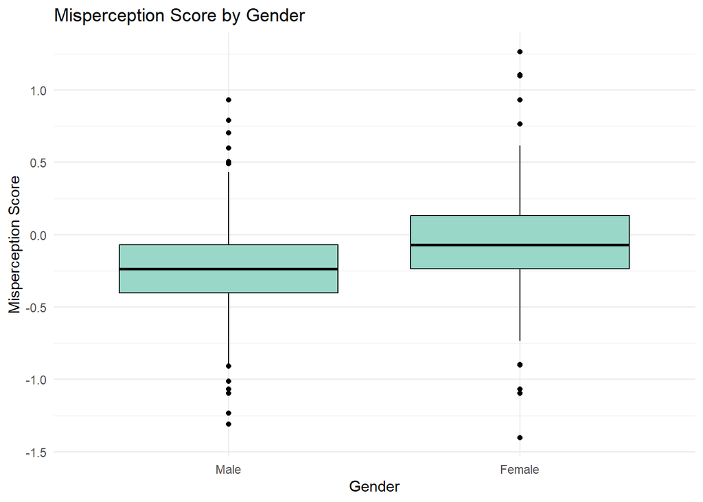

```r
ggplot(d, aes(x = factor(gender, labels = c("Male", "Female")), y = misperception_score)) +
  geom_boxplot(fill = "#99d8c9", color = "black") +
  labs(
    title = "Misperception Score by Gender",
    x = "Gender",
    y = "Misperception Score"
  ) +
  theme_minimal()
```

### Correlation test

- H0: ρ*=*0 (meaning that there is no linear relationship between the two variables)
- H1: ρ≠0 (meaning that there is a linear relationship between the two variables)

```r
# Pearson correlation test
test1 <- cor.test(d$pa_mean_2, d$pn_mean_2)
test1
```

```
##
##  Pearson's product-moment correlation
##
## data:  d$pa_mean_2 and d$pn_mean_2
## t = 18.814, df = 1239, p-value < 2.2e-16
## alternative hypothesis: true correlation is not equal to 0
## 95 percent confidence interval:
##  0.4269468 0.5135690
## sample estimates:
##      cor
## 0.471394
```

What we are actually testing is whether:

- the sample contains sufficient evidence to reject the null hypothesis and conclude that the correlation coefficient does not equal 0, so the relationship exists in the population.
- or on the contrary, the sample does not contain enough evidence that the correlation coefficient does not equal 0, so in this case we do not reject the null hypothesis of no relationship between the variables in the population.

### Run the correlation test on the variables `'married'` and `'pa_mean_2'`. What is the result?

```r
test2 <- cor.test(d$married, d$pa_mean_2,
                  method = "spearman")
test2
```

```
##
##  Spearman's rank correlation rho
##
## data:  d$married and d$pa_mean_2
## S = 359204015, p-value = 0.5465
## alternative hypothesis: true rho is not equal to 0
## sample estimates:
##       rho
## 0.0167471
```

### Correlation test **for several pairs of variables**

```r
res <- rcorr(as.matrix(d_reg_summary)) # rcorr() is a function from Hmisc package, it accepts matrices only

# display p-values (rounded to 3 decimals)
round(res$P, 3)
```

```
##                     pa_mean_2 pn_mean_2 misperception_score agecat5 urban  male
## pa_mean_2                  NA     0.000               0.000   0.171 0.000 0.000
## pn_mean_2               0.000        NA               0.000   0.000 0.000 0.000
## misperception_score     0.000     0.000                  NA   0.000 0.000 0.000
## agecat5                 0.171     0.000               0.000      NA 0.000 0.000
## urban                   0.000     0.000               0.000   0.000    NA 0.000
## male                    0.000     0.000               0.000   0.000 0.000    NA
## educat3                 0.000     0.452               0.572   0.000 0.001 0.000
## income_perception       0.087     0.078               0.093   0.989 0.028 0.307
## quran                   0.000     0.765               0.773   0.000 0.108 0.000
## married                 0.573     0.000               0.000   0.000 0.000 0.000
##                     educat3 income_perception quran married
## pa_mean_2             0.000             0.087 0.000   0.573
## pn_mean_2             0.452             0.078 0.765   0.000
## misperception_score   0.572             0.093 0.773   0.000
## agecat5               0.000             0.989 0.000   0.000
## urban                 0.001             0.028 0.108   0.000
## male                  0.000             0.307 0.000   0.000
## educat3                  NA             0.000 0.004   0.000
## income_perception     0.000                NA 0.783   0.276
## quran                 0.004             0.783    NA   0.000
## married               0.000             0.276 0.000      NA
```

## Regressions

### Ordinary List Squares regression

- is a statistical method used for modeling the relationship between a dependent variable (or outcome) and one or more independent variables (or predictors) by finding the best-fitting linear equation.
- The goal of OLS regression is to estimate the coefficients of the linear equation in such a way that it minimizes the sum of the squared differences between the observed and predicted values of the dependent variable.

```r
#Y = β0 + β1*X1 + β2*X2 + ... + βn*Xn + ε
```

```r
# DV: personal attitudes (PA)score
mod1 <- lm(pa_mean_2 ~ factor(agecat5) + urban + male + factor(educat3) + income_perception + quran + married, data = d)

summary(mod1)
```

```
##
## Call:
## lm(formula = pa_mean_2 ~ factor(agecat5) + urban + male + factor(educat3) +
##     income_perception + quran + married, data = d)
##
## Residuals:
##      Min       1Q   Median       3Q      Max
## -1.92030 -0.26838 -0.02239  0.25755  1.43507
##
## Coefficients:
##                    Estimate Std. Error t value Pr(>|t|)
## (Intercept)        1.815848   0.062831  28.900  < 2e-16 ***
## factor(agecat5)2  -0.061591   0.034738  -1.773  0.07647 .
## factor(agecat5)3  -0.081497   0.040853  -1.995  0.04628 *
## factor(agecat5)4  -0.032334   0.046552  -0.695  0.48746
## factor(agecat5)5   0.032085   0.051141   0.627  0.53053
## urban              0.014980   0.029314   0.511  0.60943
## male              -0.263383   0.027321  -9.640  < 2e-16 ***
## factor(educat3)2   0.117447   0.038566   3.045  0.00237 **
## factor(educat3)3   0.206543   0.037887   5.452 6.03e-08 ***
## income_perception  0.007375   0.012849   0.574  0.56609
## quran             -0.062225   0.012053  -5.163 2.84e-07 ***
## married           -0.010486   0.031258  -0.335  0.73732
## ---
## Signif. codes:  0 '***' 0.001 '**' 0.01 '*' 0.05 '.' 0.1 ' ' 1
##
## Residual standard error: 0.4168 on 1225 degrees of freedom
##   (65 observations deleted due to missingness)
## Multiple R-squared:  0.1195, Adjusted R-squared:  0.1116
## F-statistic: 15.12 on 11 and 1225 DF,  p-value: < 2.2e-16
```

### Run the same code where DV is *`perceived norms (PN) score`*, name the model ‘mod2’

```r
mod2 <- lm(... ~ factor(agecat5) + urban + male + factor(educat3) + ... + ... + ..., ... = d)

summary(...)
```

### Regression table output with ‘stargazer’ package

```r
stargazer(
  mod1,
  type = "text",  # Set the output type to 'text'
  title = "Regression Results"
)
```

```
##
## Regression Results
## ===============================================
##                         Dependent variable:
##                     ---------------------------
##                              pa_mean_2
## -----------------------------------------------
## factor(agecat5)2              -0.062*
##                               (0.035)
##
## factor(agecat5)3             -0.081**
##                               (0.041)
##
## factor(agecat5)4              -0.032
##                               (0.047)
##
## factor(agecat5)5               0.032
##                               (0.051)
##
## urban                          0.015
##                               (0.029)
##
## male                         -0.263***
##                               (0.027)
##
## factor(educat3)2             0.117***
##                               (0.039)
##
## factor(educat3)3             0.207***
##                               (0.038)
##
## income_perception              0.007
##                               (0.013)
##
## quran                        -0.062***
##                               (0.012)
##
## married                       -0.010
##                               (0.031)
##
## Constant                     1.816***
##                               (0.063)
##
## -----------------------------------------------
## Observations                   1,237
## R2                             0.120
## Adjusted R2                    0.112
## Residual Std. Error      0.417 (df = 1225)
## F Statistic          15.117*** (df = 11; 1225)
## ===============================================
## Note:               *p<0.1; **p<0.05; ***p<0.01
```

### Plotting OLS results with coefplots from ‘modelsummary’ package

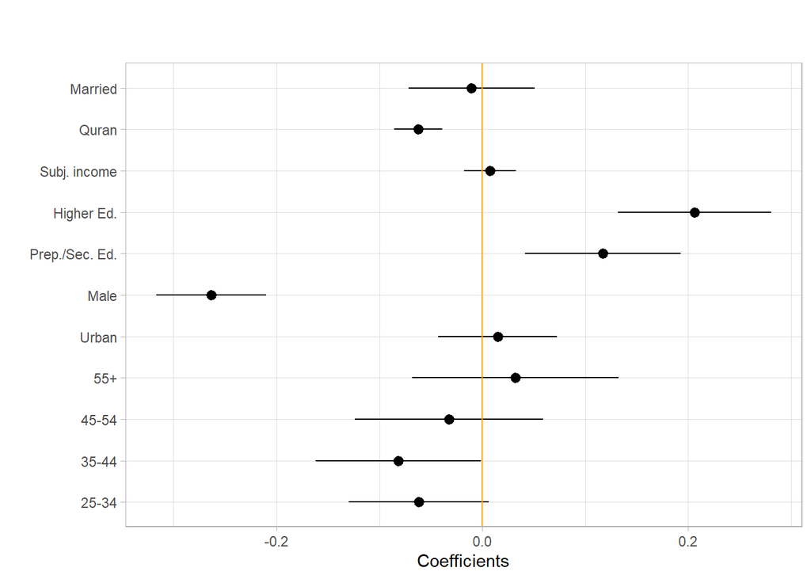

```r
covnames = c('factor(agecat5)2' = '25-34',
         'factor(agecat5)3' = '35-44',
         'factor(agecat5)4' = '45-54',
         'factor(agecat5)5' = '55+',
         'urban' = 'Urban',
         'male' = 'Male',
         'factor(educat3)2' = 'Prep./Sec. Ed.',
         'factor(educat3)3' = 'Higher Ed.',
         'income_perception' = 'Subj. income',
         'quran' = 'Quran',
         'married' = 'Married')

modelplot(mod1, coef_map = covnames) +
  geom_vline(xintercept = 0, col = "orange") +
  labs(
    x = "Coefficients",
    title = "",
    subtitle = ""
    ) +
  theme_light()
```

### Logistic regression: overestimation of conservatism

In logistic regression, the output is modeled as the probability of the dependent variable being in one of the two categories. The logistic function is used to model this probability, ensuring that the predicted values fall between 0 and 1.

So, how do we interpret the results?

```r
# telephone survey
mod3 <- glm(overestimate ~ factor(agecat5) + urban + male + factor(educat3) + income_perception + quran + married, data = d, family = "binomial")

summary(mod3)
```

```
##
## Call:
## glm(formula = overestimate ~ factor(agecat5) + urban + male +
##     factor(educat3) + income_perception + quran + married, family = "binomial",
##     data = d)
##
## Coefficients:
##                    Estimate Std. Error z value Pr(>|z|)
## (Intercept)        0.691625   0.335393   2.062   0.0392 *
## factor(agecat5)2   0.105543   0.190404   0.554   0.5794
## factor(agecat5)3  -0.088101   0.215081  -0.410   0.6821
## factor(agecat5)4  -0.248856   0.242123  -1.028   0.3040
## factor(agecat5)5  -0.280474   0.268325  -1.045   0.2959
## urban              0.020347   0.156492   0.130   0.8966
## male               0.797266   0.146993   5.424 5.83e-08 ***
## factor(educat3)2  -0.047517   0.205729  -0.231   0.8173
## factor(educat3)3  -0.225959   0.200943  -1.124   0.2608
## income_perception -0.102446   0.069080  -1.483   0.1381
## quran              0.006491   0.064561   0.101   0.9199
## married           -0.002637   0.162083  -0.016   0.9870
## ---
## Signif. codes:  0 '***' 0.001 '**' 0.01 '*' 0.05 '.' 0.1 ' ' 1
##
## (Dispersion parameter for binomial family taken to be 1)
##
##     Null deviance: 1507.7  on 1183  degrees of freedom
## Residual deviance: 1454.3  on 1172  degrees of freedom
##   (118 observations deleted due to missingness)
## AIC: 1478.3
##
## Number of Fisher Scoring iterations: 4
```

```r
# online survey
mod4 <- glm(overestimate ~ factor(agecat5) + urban + male + factor(educat3) + income_perception + religiosity + married, data = o, family = "binomial")

summary(mod4)
```

```
##
## Call:
## glm(formula = overestimate ~ factor(agecat5) + urban + male +
##     factor(educat3) + income_perception + religiosity + married,
##     family = "binomial", data = o)
##
## Coefficients:
##                    Estimate Std. Error z value Pr(>|z|)
## (Intercept)        3.138742   0.672944   4.664  3.1e-06 ***
## factor(agecat5)2  -0.168003   0.207515  -0.810  0.41817
## factor(agecat5)3  -0.396337   0.231552  -1.712  0.08696 .
## factor(agecat5)4  -0.390822   0.325258  -1.202  0.22953
## factor(agecat5)5  -0.432810   0.438578  -0.987  0.32372
## urban             -1.014106   0.526865  -1.925  0.05426 .
## male               0.430384   0.152942   2.814  0.00489 **
## factor(educat3)2  -0.126024   0.316928  -0.398  0.69089
## factor(educat3)3  -0.448208   0.312403  -1.435  0.15137
## income_perception -0.015918   0.091065  -0.175  0.86124
## religiosity       -0.105975   0.127174  -0.833  0.40467
## married           -0.009405   0.173358  -0.054  0.95673
## ---
## Signif. codes:  0 '***' 0.001 '**' 0.01 '*' 0.05 '.' 0.1 ' ' 1
##
## (Dispersion parameter for binomial family taken to be 1)
##
##     Null deviance: 1172.4  on 1290  degrees of freedom
## Residual deviance: 1145.9  on 1279  degrees of freedom
## AIC: 1169.9
##
## Number of Fisher Scoring iterations: 5
```

- Positive Coefficient: An increase in the predictor variable is associated with an increase in the log-odds of the outcome variable being in the “success” category (the probability of success increases).
- Negative Coefficient: An increase in the predictor variable is associated with a decrease in the log-odds of the outcome variable being in the “success” category (the probability of success decreases).

It’s common practice to exponentiate the coefficients to obtain odds ratios, which provide a more interpretable measure of the impact of predictors on the odds of success. An odds ratio greater than 1 suggests an increase in the odds of success, while an odds ratio less than 1 suggests a decrease.

### Regression table output with ‘modelsummary’ package

```r
# Create a list of your logistic regression models
models <- list(
  "Telephone Survey" = mod3,
  "Online Survey" = mod4
)

# Summarize the models and request odds ratios
model_summary <- modelsummary(
  models,
  exponentiate = TRUE,  # Request odds ratios
  stars = TRUE          # Add significance stars
)
```

### Plotting logistic model’s results

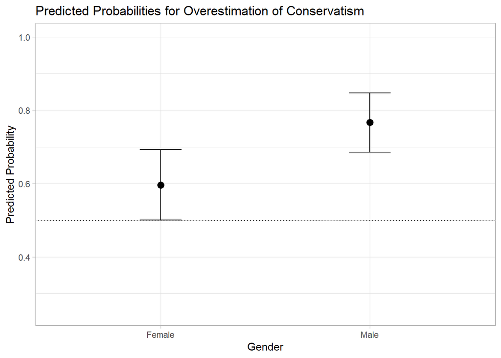

```r
# We first create a new df to provide a set of predictor variables with specific values for which we want to predict probabilities using logistic regression model - mod3

# Predicted probabilities at mean values:

newdata_t <- with(d, data.frame(male = c(0, 1),
                                agecat5 = 3,
                                urban = 1,
                                educat3 = 2,
                                income_perception = 2,
                                quran = 3,
                                married = 0))

pred_t <- predict(mod3,
                  newdata_t,
                  type = "response",
                  se.fit = TRUE)

# Create a data frame for the Telephone survey
results_telephone <- data.frame(
  Gender = c("Female", "Male"),
  Estimate = pred_t$fit,
  SE = pred_t$se.fit # the se.fit = TRUE argument also calculates the standard errors of the predicted probabilities
)

# Plot results for the Telephone survey
ggplot(results_telephone, aes(x = Gender, y = Estimate)) +
  geom_point(size = 3) +
  geom_errorbar(aes(ymin = Estimate - 1.96 * SE, ymax = Estimate + 1.96 * SE), width = 0.2, color = "black") +
  geom_hline(yintercept = 0.5, linetype = 3, color = "black") +
  scale_y_continuous(limits = c(0.25, 1)) +
  labs(
    title = "Predicted Probabilities for Overestimation of Conservatism",
    y = "Predicted Probability"
  ) +
  theme_light()
```

## Best practices: creation of html or pdf document

**For HTML Output:**

1. Open your R Markdown (.Rmd) file in RStudio or your preferred R Markdown editor.
2. At the top of your .Rmd file, specify the output format as HTML by adding the following YAML header:

```r
---
title: "Your Document Title"
    output:
      html_document:
        theme: "cosmo"  # Choose an HTML theme (optional)
---
```

3. Save the .Rmd file.
4. Click the “Knit” button in RStudio, or use the following R command to render the HTML:

```r
rmarkdown::render("your_file.Rmd")
```

5. R Markdown will compile your document into an HTML file. Once the process is complete, you’ll find the HTML file in the same directory as your .Rmd file.

**For PDF Output:**

1. Ensure you have LaTeX installed on your system. LaTeX is required to compile R Markdown documents into PDFs. You can download and install LaTeX from the official website (e.g., MiKTeX for Windows, MacTeX for macOS, or TeX Live for Linux).
2. Open your R Markdown (.Rmd) file in RStudio or your preferred R Markdown editor.
3. At the top of your .Rmd file, specify the output format as PDF by adding the following YAML header:

```r
---
title: "Your Document Title"
output:
  pdf_document
---
```

4. Save the .Rmd file.
5. Click the “Knit” button in RStudio, or use the following R command to render the PDF:

```r
rmarkdown::render("your_file.Rmd")
```

# Random sampling

1. Sample function

```r
# Create a dataset
dataset1 <- 1:100

# Set a random seed for reproducibility: it guarantees that the same random values are produced each time you run the code
set.seed(123)

# Create a simple random sample of size 10
random_sample1 <- sample(dataset1, size = 10)
random_sample1
```

```
##  [1] 31 79 51 14 67 42 50 43 97 25
```

In this example, we first create a dataset **`dataset`** containing numbers from 1 to 100. We set a random seed using **`set.seed`** for reproducibility (optional). Then, we use the **`sample`** function to draw a simple random sample of size 10 from the **`dataset`**. Thus, **`sample`** is used for random sampling from a given set of values.

2. Runif function – generates random numbers from a uniform distribution

In a uniform distribution, all values within a specific range are equally likely to occur (remember a six-sided die?)

```r
set.seed(456) # Setting seed for reproducibility

n <- 150 # establishing the number of observations you want in your dataset

continuous <- runif(n, min = 0, max = 100) # n random numbers from a uniform distribution between 0 and 100

binary <- sample(0:1, n, replace = TRUE) # selects n values from the sequence 0 to 1 with replacement, meaning that the same number can be picked more than once

dataset2 <- data.frame(var1 = continuous,
                       var2 = binary)
dataset2
```

```
##           var1 var2
## 1    8.9551600    0
## 2   21.0512319    0
## 3   73.2955268    1
## 4   85.2133541    1
## 5   78.8397894    1
## 6   33.1959968    0
## 7    8.2432735    1
## 8   28.5526945    1
## 9   23.7503272    1
## 10  38.5236167    0
## 11  37.2945911    1
## 12  21.7908560    0
## 13  75.5105035    0
## 14  82.1681069    1
```

[output cut: 136 more lines]

3. Rnorm function – generates random numbers from a normal (Gaussian) distribution

```r
set.seed(928)

dataset3 <- data.frame(
  ID = letters[1:20],
  Var1 = rnorm(20),
  Var2 = sample(0:1, 20, replace = TRUE)
)

dataset3
```

```
##    ID        Var1 Var2
## 1   a -1.19771875    1
## 2   b  1.23719408    1
## 3   c -0.56205523    0
## 4   d  0.22445288    1
## 5   e -0.95957824    1
## 6   f  2.06931922    1
## 7   g -0.01144550    1
## 8   h  0.41035773    0
## 9   i  1.54760735    0
## 10  j  1.18981168    1
## 11  k -0.44031209    0
## 12  l -0.13455712    1
## 13  m  1.08745229    1
## 14  n -2.12429312    1
## 15  o -0.48525742    0
## 16  p  0.08218756    0
## 17  q  1.82446831    0
## 18  r -0.65443680    0
## 19  s  1.51143655    0
## 20  t  0.95644143    1
```

### Exercise: create a dataset simulating social attitudes and perform various analyses on it

Create a dataset with 1670 observations and the following variables:

- **Dependent Variables:**
  1. **Voting for Fight-Rights (Binary Indicator):** 0 (No) or 1 (Yes)
  2. **Conservatism Perceptions Score (Continuous):** Varying from 1 to 5
- **Independent Variables:**
  1. **Racial Prejudices (Binary):** 0 (No) or 1 (Yes)
  2. **Employment Type:**
     - 0: Unemployed
     - 1: Blue-collar
     - 2: Farmer/Self-employed
     - 3: White-collar

  **Perform Analyses**
  1. **Correlation Analysis:**
     - Compute the correlation between having racial prejudices and the index of conservatism perceptions.
  2. **Visualization:**
     - Create a boxplot visualizing the relationships between conservatism perceptions score, racial prejudices, and employment type.
  3. **Linear Regression:**
     - Run a linear regression on conservatism perceptions score with racial prejudices and employment type as independent variables.
  4. **Logistic Regression:**
     - Run a logistic regression on voting for fight-rights with racial prejudices and employment type as independent variables.

```r
# Step 1: Creating the Dataset
set.seed(123) # Setting seed for reproducibility
n <- 1670
```

```r
# Generating data for the variables
var1 <- sample(0:1, n, replace = TRUE)
var2 <- runif(n, min = 1, max = 5)
var3 <- sample(0:1, n, replace = TRUE)
var4 <- sample(0:3, n, replace = TRUE)
```

```r
# Creating the dataset
social_attitudes <- data.frame(
  Voting = var1,
  Conservatism = var2,
  Racial_Prejudices = var3,
  Employment_Type = var4
)
```

```r
# Step 2: Perform Analyses

# 1. Correlation Analysis
correlation <- cor.test(social_attitudes$Racial_Prejudices, social_attitudes$Conservatism)
correlation
```

```
##
##  Pearson's product-moment correlation
##
## data:  social_attitudes$Racial_Prejudices and social_attitudes$Conservatism
## t = -0.0029454, df = 1668, p-value = 0.9977
## alternative hypothesis: true correlation is not equal to 0
## 95 percent confidence interval:
##  -0.04803943  0.04789552
## sample estimates:
##           cor
## -7.211747e-05
```

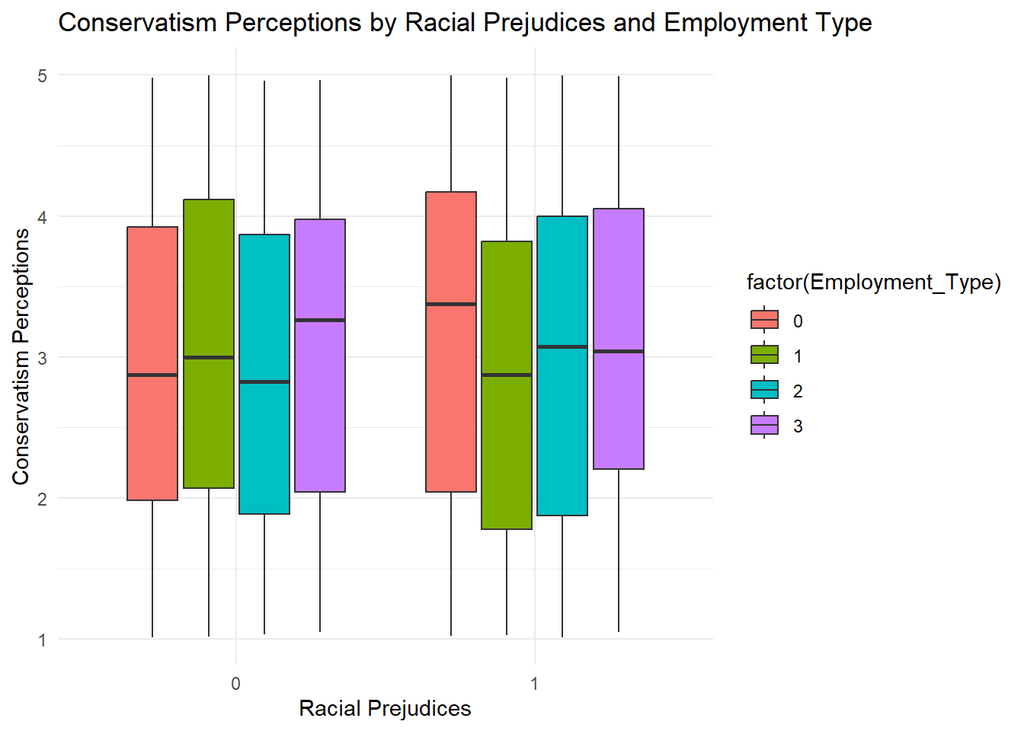

```r
# 2. Visualization (Boxplot)
ggplot(social_attitudes, aes(x = factor(Racial_Prejudices), y = Conservatism, fill = factor(Employment_Type))) +
  geom_boxplot() +
  labs(title = "Conservatism Perceptions by Racial Prejudices and Employment Type",
       x = "Racial Prejudices", y = "Conservatism Perceptions")+
  theme_minimal()
```

```r
# 3. Linear Regression
summary(linear_model <- lm(Conservatism ~ Racial_Prejudices + Employment_Type, data = social_attitudes))
```

```
##
## Call:
## lm(formula = Conservatism ~ Racial_Prejudices + Employment_Type,
##     data = social_attitudes)
##
## Residuals:
##      Min       1Q   Median       3Q      Max
## -1.99323 -1.03535  0.00459  0.98631  1.99254
##
## Coefficients:
##                     Estimate Std. Error t value Pr(>|t|)
## (Intercept)        3.0072967  0.0559712  53.729   <2e-16 ***
## Racial_Prejudices -0.0001535  0.0570805  -0.003    0.998
## Employment_Type   -0.0005403  0.0255503  -0.021    0.983
## ---
## Signif. codes:  0 '***' 0.001 '**' 0.01 '*' 0.05 '.' 0.1 ' ' 1
##
## Residual standard error: 1.164 on 1667 degrees of freedom
## Multiple R-squared:  2.735e-07,  Adjusted R-squared:  -0.001199
## F-statistic: 0.0002279 on 2 and 1667 DF,  p-value: 0.9998
```

```r
# 4. Logistic Regression
summary(logistic_model <- glm(Voting ~ Racial_Prejudices + Employment_Type, data = social_attitudes, family = binomial))
```

```
##
## Call:
## glm(formula = Voting ~ Racial_Prejudices + Employment_Type, family = binomial,
##     data = social_attitudes)
##
## Coefficients:
##                    Estimate Std. Error z value Pr(>|z|)
## (Intercept)        0.006336   0.096147   0.066    0.947
## Racial_Prejudices -0.029738   0.098061  -0.303    0.762
## Employment_Type   -0.014662   0.043896  -0.334    0.738
##
## (Dispersion parameter for binomial family taken to be 1)
##
##     Null deviance: 2314.7  on 1669  degrees of freedom
## Residual deviance: 2314.5  on 1667  degrees of freedom
## AIC: 2320.5
##
## Number of Fisher Scoring iterations: 3
```